# Your Document Title

## 4. R Markdown语法

### 4.1 标题

使用 `#` 符号来定义标题，`#` 的数量决定了标题的级别。

```markdown
# 一级标题
## 二级标题
### 三级标题
```

下面为”临床试验药物A与药物B的疗效对比”的例子：

```markdown
# 临床试验药物A与药物B的疗效对比

## 摘要

本研究旨在比较药物A和药物B在治疗某种疾病上的疗效。通过对临床试验数据的分析，我们得出了以下结论...

## 数据和方法

### 数据来源

#### 基本信息
#### 基线病情
#### 药物治疗数据
```

### 4.2 段落

直接输入文本即可创建段落，或通过添加两个空格在Markdown中实现换行

```markdown
这是一个段落。

这是另一个段落。
```

请注意，Rmarkdown支持Markdown语法以及HTML标签的嵌入。因此，可以根据需要使用Markdown的语法规则或HTML标签来实现段落的表示和换行。

### 4.3 列表

- 无序列表使用 `-`、`*` 或 `+` 符号。
- 有序列表使用数字加 `.`。
- 任务列表（GFM扩展）用`- [ ]`或用`- [x]`。

下面是一些应用列表的实例：

#### 4.3.1 无序列表：公共卫生预防措施

- 戴口罩：在公共场所和人群密集区域佩戴口罩，减少呼吸道传染病的传播。
- 勤洗手：定期用肥皂和水洗手，或使用含酒精的手部消毒液。
- 保持社交距离：与他人保持至少1米的距离，减少接触传播的风险。
- 避免聚集：减少参加大型聚会和活动的次数，降低感染风险。

#### 4.3.2 有序列表：临床试验阶段

1. **预备阶段**：设计试验方案，确定研究对象、干预措施、样本量等。
2. **招募阶段**：按照试验方案招募受试者，并进行基线评估。
3. **干预阶段**：对受试者实施干预措施，并记录相关数据。
4. **随访阶段**：按照试验方案对受试者进行随访，收集干预后的数据。
5. **数据分析与报告**：对收集到的数据进行统计分析，撰写研究报告或论文。

#### 4.3.3 任务列表（GFM扩展）：公共卫生应急响应计划

- 设立应急响应小组，明确职责和分工。
- 制定应急响应预案，包括物资准备、人员调配等。
- 开展应急演练，检验预案的可行性和有效性。
- 监测疫情动态，及时发布预警信息。
- 加强国际合作，共同应对全球公共卫生挑战。

### 4.4 强调

- 粗体文本使用 `**` 或 `__`。
- 斜体文本使用 `*` 或 `_`。

```markdown
**新药A在治疗高血压方面的疗效显著**。通过一项为期12周的临床试验，我们发现使用新药A治疗的高血压患者，其血压控制率达到了**85%**。与此同时，*患者的生活质量也得到了显著提升*。
```

### 4.5 代码块

在R Markdown中，代码块是用来嵌入可执行代码的重要部分。这些代码块可以是R代码、Python代码、SQL查询等，取决于你选择的文档引擎和内核。

#### 4.5.1 使用方法

在R Markdown中，可以使用三个反引号（```）来创建一个代码块，并在第一行的反引号后指定代码语言（如`r`、`python`、`sql`等），以便进行语法高亮。

**示例：R代码块**

假设我们想要使用读取cars数据集来进行一些基本的数据分析。下面是一个R代码块的示例：

```r
# 不需要加载额外的R包，因为cars数据集是内置的

# 查看cars数据集的前几行
head(cars)
```

```
##   speed dist
## 1     4    2
## 2     4   10
## 3     7    4
## 4     7   22
## 5     8   16
## 6     9   10
```

```r
# 计算速度（speed）的平均值
mean_speed <- mean(cars$speed)

# 计算停止距离（dist）的中位数
median_dist <- median(cars$dist)

# 输出结果
cat("速度（speed）的平均值为：", mean_speed, "\n")
```

```
## 速度（speed）的平均值为： 15.4
```

```r
cat("停止距离（dist）的中位数为：", median_dist, "\n")
```

```
## 停止距离（dist）的中位数为： 36
```

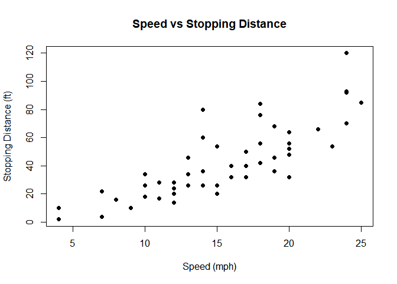

```r
# 绘制速度与停止距离的关系图
plot(cars$speed, cars$dist, main = "Speed vs Stopping Distance", xlab = "Speed (mph)", ylab = "Stopping Distance (ft)", pch = 19)
```

#### 4.5.2 代码块属性

RMarkdown文件中的R代码可以单独执行，也可以作为一个整体执行。代码块的执行结果可以直接嵌入到Markdown文本中，或者作为独立的代码块输出。

RMarkdown中的代码块可以通过设置不同的参数来控制代码的执行和输出，以下是一些常用的代码块属性：

- `echo`：控制代码是否显示在文档中。
- `eval`：决定代码是否被执行。
- `results`：设置执行结果的显示方式。
- `warning`、`message`、`error`：分别控制警告、消息和错误信息的显示。
- `cache`：允许代码块的结果被缓存，以提升性能。

#### 4.5.3 R 代码执行与输出

- 在 R Markdown 文档中，可以直接嵌入 R 代码，并展示其输出。

```
## [1] 2
```

例子中，`echo=FALSE` 表示不显示代码本身，`message=FALSE` 表示不显示 R 运行时的消息。

### 4.6 链接

在R Markdown中，创建超链接的基本语法是使用方括号`[]`包围链接文本，紧接着使用圆括号`()`包围链接地址。这种语法可以在文档中直接添加指向其他网页、文档或资源的链接，使内容更加丰富和具有交互性。

假设我们正在撰写一篇关于”新冠病毒疫苗接种效果分析”的R Markdown文档，并想引用世界卫生组织（WHO）发布的最新报告。我们可以使用以下语法来创建一个链接：

```markdown
根据[世界卫生组织（WHO）的最新报告](https://www.who.int/publications/m/item/weekly-epidemiological-update---23-august-2023)，新冠病毒疫苗的接种效果在不同人群中有所差异。
```

在示例中，链接文本是”世界卫生组织（WHO）的最新报告”，而链接地址是`https://www.who.int/publications/m/item/weekly-epidemiological-update---23-august-2023`，读者可以点击这个链接，直接访问WHO发布的最新报告，获取更详细的信息。

除了引用外部资源，你还可以使用链接来跳转到文档的其他部分。这对于长篇文档来说非常有用，可以帮助读者快速定位到感兴趣的内容。例如，你可以使用以下语法来创建一个指向文档中某个章节的链接：

```markdown
关于R markdown与markdown的对比，请参见[3.1 R markdown与markdown异同](### 3.1 R markdown与markdown异同)。
```

在这个示例中，链接文本是”3.1 R markdown与markdown异同”，而链接地址是一个特殊的标识符`### 3.1 R markdown与markdown异同`。这个标识符对应于文档中某个标题的ID，通过点击这个链接，读者可以快速跳转到该标题所在的位置。

### 4.7 图片

在R Markdown中，图片的插入同样和链接类似，非常简单且直观。

图片可能用于展示网络或本地图像、数据可视化结果、流程图等。以下是一些具体的示例和语法：

#### 4.7.1 插入网络图片

如果有一个图片的有效网络连接（即图片的URL），可以直接使用以下语法来插入它：

```markdown
![图片说明](图片URL)
```

例如，如果想插入一张展示新冠病毒传播路径的流程图，你可以这样做：

```markdown
![新冠病毒传播路径](https://cn.bing.com/images/search?view=detailV2&ccid=SZ4lvUG%2b&id=781CCEB459267D6D14A1F487CF1D467C48A63D40&thid=OIP.SZ4lvUG-fb6orbvVSZdj1wHaEB&mediaurl=https%3a%2f%2friph.nankai.edu.cn%2f_upload%2farticle%2fimages%2fe2%2f20%2fd751bab942c5a716f792813859ef%2ffbe46f9f-4027-4f1d-b13d-a7cf64f7500e.gif&cdnurl=https%3a%2f%2fts1.cn.mm.bing.net%2fth%2fid%2fR-C.499e25bd41be7dbea8adbbd5499763d7%3frik%3dQD2mSHxGHc%252bH9A%26pid%3dImgRaw%26r%3d0&exph=770&expw=1419&q=%e6%96%b0%e5%86%a0%e7%97%85%e6%af%92%e4%bc%a0%e6%92%ad%e8%b7%af%e5%be%84&simid=607990988477242474&FORM=IRPRST&ck=554914B8267CBA9B814DD3132B44A0B5&selectedIndex=1&itb=0&ajaxhist=0&ajaxserp=0)
```

#### 4.7.2 插入本地图片

如果有一个保存在本地文件夹中的图片，可以使用相对路径或绝对路径来引用它。由于绝对路径在不同的环境下可能无法有效加载图片，所以推荐使用相对路径。

相对路径是相对于你的R Markdown文件所在的位置的路径。例如，如果你的R Markdown文件在`C:/Users/YourName/Documents/Project`文件夹中，而你的图片在`C:/Users/YourName/Documents/Project/Images`文件夹中，那么你可以使用以下语法来插入图片：

```markdown
![图片说明](Images/your-image.png)
```

注意，这里的`Images/your-image.png`就是相对于R Markdown文件的相对路径。

#### 4.7.3 插入R代码块生成的图片

下面案例为使用 R 绘图函数（如 `plot()`、`ggplot2` 等）在 R Markdown 中创建图表，并直接在文档中展示。

**疾病防控案例：传染病监测数据**

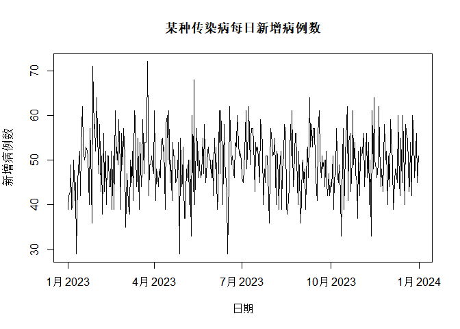

```r
# 加载需要的库（这里不需要ggplot2或dplyr，但为了完整性，我保留了它们的加载）
library(ggplot2)
library(dplyr)
# 创建2023年1月1日到2023年12月31日每天对应的新增病例数数据框
daily_cases <- data.frame(
  Date = seq.Date(from = as.Date("2023-01-01"), to = as.Date("2023-12-31"), by = "day"),
  Cases = rpois(365, 50)  # 生成365个随机数，均值为50的泊松分布
)


# 使用 base R 绘简单的线图
plot(x = daily_cases$Date, y = daily_cases$Cases, type = 'l',
     xlab = "日期", ylab = "新增病例数",
     main = "某种传染病每日新增病例数")
```

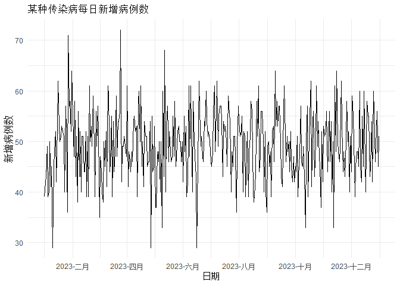

```r
# 使用 ggplot2 绘图
library(ggplot2)
ggplot(data = daily_cases, aes(x = Date, y = Cases)) +
  geom_line() +
    scale_x_date(breaks = "2 month", date_labels = "%Y-%B") +  # 设置X轴日期格式
  labs(title = "某种传染病每日新增病例数", x = "日期", y = "新增病例数") +
  theme_minimal()
```

**临床案例：治疗方法对患者生存率的影响**

下面这个案例展示某种治疗方法对患者生存率的影响：假设我们有另一个数据框treatment_data，其中包含不同治疗方法（Treatment）和相应的患者1年生存率（SurvivalRate）。

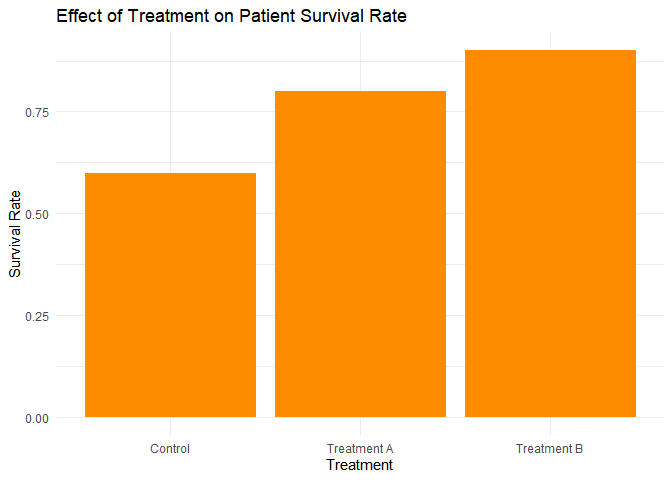

```r
# 假设的治疗数据
treatment_data <- data.frame(
  Treatment = factor(c("Treatment A", "Treatment B", "Control")),
  SurvivalRate = c(0.80, 0.90, 0.60)
)

# 生成图表
library(ggplot2)
ggplot(treatment_data, aes(x = Treatment, y = SurvivalRate)) +
  geom_bar(stat = "identity", fill = "darkorange") +
  labs(title = "Effect of Treatment on Patient Survival Rate",
       x = "Treatment",
       y = "Survival Rate") +
  theme_minimal()
```

在 R Markdown 中创建流程图或甘特图，可以用 R 包如 `mermaid.js`，或 `ggplot2`、`DiagrammeR` 等来生成图形。

**使用ggplot2 包创建甘特图**

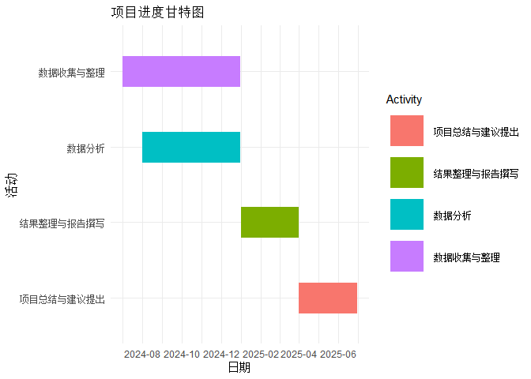

```r
if (!requireNamespace(c("ggplot2", "dplyr"), quietly = TRUE)) {
  install.packages(c("ggplot2", "dplyr"))
}

library(ggplot2)
library(dplyr)
# 创建项目活动数据
activities <- data.frame(
  Activity = c("数据收集与整理", "数据分析", "结果整理与报告撰写", "项目总结与建议提出"),
  Start = as.Date(c("2024-07-01", "2024-08-01", "2025-01-01", "2025-04-01")),
  End = as.Date(c("2024-12-31", "2024-12-31", "2025-03-31", "2025-06-30"))
)

# 重排 Activity 列，使其按照 Start 列的值降序排列
activities <- activities %>%
  mutate(Activity = factor(Activity, levels = unique(Activity)[order(Start, decreasing = T)]))

# 绘制甘特图
gantt_chart <- ggplot(activities, aes(x = Start, xend = End, y = Activity)) +
  geom_segment(aes(color = Activity), size = 14) +  # 绘制活动条形
  scale_x_date(breaks = "2 months", date_labels = "%Y-%m") +  # 设置X轴日期格式
  theme_minimal() +  # 使用简洁主题
  labs(title = "项目进度甘特图", x = "日期", y = "活动")
# 打印甘特图
print(gantt_chart)
```

**使用DiagrammeR 包创建流程图**

```r
library(DiagrammeR)
```

```r
# 安装并加载 DiagrammeR 包
if (!requireNamespace("DiagrammeR", quietly = TRUE)) {
  install.packages("DiagrammeR")
}


# 定义 Mermaid 图表代码
mermaid_code <- '
graph TD
    A[健康女性 <br> --不同年龄] --> B[HPV疫苗接种 <br> --不同策略组合]
    B --> C{疫苗覆盖型别}
    C -->|长期免疫保护| D[健康]
    C -->|未覆盖型别感染| E[其他HPV型别感染]
    E --> F[无症状或轻微症状]
    E --> G[发展为LSIL]
    G --> H[自然消退或治疗]
    G --> I[发展为HSIL]
    G --> O
    I --> J{HSIL进展}
    J -->|自然消退或治疗| K[健康]
    J -->|持续存在| L[发展为子宫颈癌]
    L --> N[子宫颈癌治愈]
    L --> M[死于子宫颈癌]
    N --> O[自然死亡]
    J --> O
    H --> O
    B --> O
    F --> O
    K --> O
    D --> O

'

# 使用 DiagrammeR 包的 mermaid() 函数渲染图表
mermaid(mermaid_code)
```

[interactive chart not shown]

#### 4.7.4. 调整图片大小

虽然Markdown本身并不直接支持调整图片大小的功能，但可以通过添加`fig.width`和`fig.height`等属性，或者通过HTML标签来实现。

**通过fig.x属性调整图片大小** 如下是在R Markdown代码块中添加`fig.width`和`fig.height`这两个属性来调整图片大小。

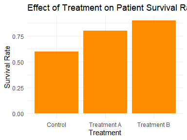

```r
# 假设的治疗数据
treatment_data <- data.frame(
  Treatment = factor(c("Treatment A", "Treatment B", "Control")),
  SurvivalRate = c(0.80, 0.90, 0.60)
)

# 生成图表
library(ggplot2)
ggplot(treatment_data, aes(x = Treatment, y = SurvivalRate)) +
  geom_bar(stat = "identity", fill = "darkorange") +
  labs(title = "Effect of Treatment on Patient Survival Rate",
       x = "Treatment",
       y = "Survival Rate") +
  theme_minimal()
```

在这个代码块中，`{r treatment-survival-plot, fig.width=4, fig.height=3}`这部分是R Markdown的”代码块标签”。在这个标签中，`treatment-survival-plot`是代码块的名称，而`fig.width=4`和`fig.height=3`则是设置图片宽度和高度的属性。这些属性将影响由该代码块生成的图片的大小。

请注意，这些尺寸是以英寸为单位的，但你也可以使用其他单位，如厘米（cm）或像素（px），只需将数字后面的单位更改为你想要的即可。例如，`fig.width=10cm`或`fig.height=500px`。

**通过HTML标签调整图片大小**

```markdown
<img src="Images/your-image.png" alt="图片说明" style="width:50%;height:auto;">
```

在这个示例中，`style="width:50%;height:auto;"`用于设置图片的宽度为50%（相对于其容器的宽度），并自动调整高度以保持图片的原始比例。

### 4.8 表格

可以在 R Markdown 中用 R 代码来直接定义、编写表格，或导入/生成表格。

在Markdown中，你可以使用管道符（|）和短横线（-）来定义一个简单的表格。以下为直接用R markdown生成标题”临床患者数据（部分）“的表格。

| 患者ID | 年龄 | 性别 | 诊断结果 | 治疗方法 |
| --- | --- | --- | --- | --- |
| 1 | 25 | 男 | 癌症 | 手术 |
| 2 | 32 | 女 | 糖尿病 | 药物治疗 |
| 3 | 48 | 男 | 心脏病 | 搭桥手术 |
| 4 | 18 | 女 | 哮喘 | 吸入器 |
| 5 | 55 | 男 | 中风 | 物理治疗 |

**R代码生成表格**

```r
# 手动创建一个临床医学数据示例
clinical_data <- data.frame(
  患者ID = 1:5,
  年龄 = c(25, 32, 48, 18, 55),
  性别 = c("男", "女", "男", "女", "男"),
  诊断结果 = c("癌症", "糖尿病", "心脏病", "哮喘", "中风"),
  治疗方法 = c("手术", "药物治疗", "搭桥手术", "吸入器", "物理治疗")
)

# 使用 knitr::kable() 函数来生成Markdown格式的表格
knitr::kable(clinical_data, caption = "临床患者数据（部分）", format = "markdown")
```

临床患者数据（部分）

| 患者ID | 年龄 | 性别 | 诊断结果 | 治疗方法 |
| --- | --- | --- | --- | --- |
| 1 | 25 | 男 | 癌症 | 手术 |
| 2 | 32 | 女 | 糖尿病 | 药物治疗 |
| 3 | 48 | 男 | 心脏病 | 搭桥手术 |
| 4 | 18 | 女 | 哮喘 | 吸入器 |
| 5 | 55 | 男 | 中风 | 物理治疗 |

使用 knitr::kable() 函数来生成Markdown格式的表格。 knitr::kable() 是一个用于生成美观表格的函数，它将数据框(data.frame)或矩阵(matrix)转换为Markdown格式，使得表格在R Markdown文档中能够以整洁的格式呈现。caption 参数用于为表格添加标题。

**R代码来导入表格**

```r
# 安装并加载readxl包（如果尚未安装）
# install.packages("readxl")
library(readxl)
# 导入Excel文件
Cars_excel_data <- read_excel("tables/Cars Data.xlsx")
# 查看数据的前几行
head(Cars_excel_data)
```

```
## # A tibble: 6 × 16
##    Make Model Type          Origin DriveTrain MSRP  Invoice EngineSize Cylinders
##   <dbl> <chr> <chr>         <chr>  <chr>      <chr>   <dbl>      <dbl>     <dbl>
## 1     2 Acura MDX           SUV    Asia       All     36945      33337       3.5
## 2     3 Acura RSX Type S 2… Sedan  Asia       Front   23820      21761       2
## 3     4 Acura TSX 4dr       Sedan  Asia       Front   26990      24647       2.4
## 4     5 Acura TL 4dr        Sedan  Asia       Front   33195      30299       3.2
## 5     6 Acura 3.5 RL 4dr    Sedan  Asia       Front   43755      39014       3.5
## 6     7 Acura 3.5 RL w/Nav… Sedan  Asia       Front   46100      41100       3.5
## # ℹ 7 more variables: Horsepower <dbl>, MPG_City <dbl>, MPG_Highway <dbl>,
## #   Weight <dbl>, Wheelbase <dbl>, Length <dbl>, ...16 <dbl>
```

### 4.9 数学公式

RMarkdown 支持使用 LaTeX 语法来插入数学公式。

RMarkdown 文档中，用 `$$` 符号来插入 LaTeX 格式的数学公式。

其中：

- $Y$ 是响应变量（例如，某种疾病的发病率）。
- $X = (x_1, x_2, \ldots, x_p)$ 是预测变量（例如，年龄、性别、环境因素等）。
- $g(\cdot)$ 是连接函数，它定义了响应变量的期望值与模型预测值之间的关系。常见的连接函数包括恒等函数（用于线性回归）、对数函数（用于泊松回归）等。
- $f_1, f_2, \ldots, f_p$ 是平滑函数，它们捕获了响应变量与每个预测变量之间的非线性关系。这些平滑函数可以是任何形状，从而允许模型适应复杂的数据模式。
- $\alpha$ 是截距项。

当渲染时，LaTeX 公式将被转换为专业的数学表达式。

### 4.10 分页符和分割线

在 R Markdown中，分页符和分割线（或称为水平线）是两个不同的概念，但都可以在文档中用来改善可读性和布局。

- 分页符

在 R Markdown 中，通常没有直接的分页符语法来强制在输出文档（如 PDF）中进行分页。但是，当生成 PDF 时，我们可能希望使用 LaTeX 的功能来实现分页。但是，请注意，这通常是在我们使用的特定 R Markdown 模板（如 pandoc 的 LaTeX 模板）中控制的，而不是直接在 R Markdown 文档中。

如果用像 bookdown 这样的R包来编写书籍或长文档，则可以使用 `\newpage` 或 `\clearpage` 在 LaTeX 输出中强制分页。

- 分割线

用 HTML 或 Markdown 的语法来添加分割线。以下是示例：

```markdown
---

这是一条分割线。

或用三个或更多的连字符、星号或下划线来创建一条水平线：

***

或者

---

或者

___
```

上述这些都将在生成的文档（ HTML、PDF 等）中显示为一条水平线（注意，这些水平线在纯文本输出（如 Markdown 文件）中可能无法正确显示）。

### 4.11 导出文档与分享

RMarkdown 文件可导出为多种格式，包括 HTML、Word、PDF 等。以下是如何使用 RMarkdown 导出这些格式的详细说明：

#### 导出 HTML

(1)**确保指定输出格式为HTML**：在文件的 YAML 头部中，设置 `output` 为 `html_document`。可以进一步定制输出选项，如选择主题、添加 CSS 样式等。

```yaml
---
title: "RMarkdown 示例"
author: "你的名字"
date: "2024年5月22日"
output: html_document
---
```

(2)**导出 HTML**

可以点击 RStudio 工具栏上的 “Knit” 按钮（或使用快捷键 Ctrl + Shift + K），选择 “Knit to HTML”。这将生成一个 HTML 文件，在浏览器中打开。

#### 导出 Word

(1)**修改输出格式**：在 YAML 头部中，将 `output` 设置为 `word_document`。

```yaml
---
title: "RMarkdown 示例"
author: "你的名字"
date: "2024年5月22日"
output: word_document
---
```

(2)**编写和导出**：编写.rmd内容后，点击 “Knit” 按钮，选择 “Knit to Word”。这将生成一个 Word 文件。

#### 导出 PDF

要导出为 PDF，通常需要使用 `pdf_document` 或 `latex_document` 格式，并通过 LaTeX 编译器（如 pandoc 或 XeLaTeX）进行转换。

(1)**确保已安装 LaTeX 等编译器**： LaTeX ，MiKTeX ，MacTeX 等。

(2)**修改输出格式**：在 YAML 头部中，将 `output` 设置为 `pdf_document` 或 `latex_document`。

```yaml
---
title: "RMarkdown 示例"
author: "你的名字"
date: "2024年5月22日"
output: pdf_document
---
```

#### 导出其他格式

RMarkdown 还支持其他输出格式，如 PowerPoint（`powerpoint_presentation`）、幻灯片（`slidy_presentation`、`revealjs::revealjs_presentation`、`beamer_presentation`）、电子书（`epub_document`）等。我们可以通过修改 YAML 头部中的 `output` 字段来指定你想要的输出格式。然后，使用 “Knit” 按钮来生成对应的文件。

请注意，某些格式可能需要额外的依赖项或工具链来正常工作。例如，要导出为电子书，可能需要安装 Calibre 或其他电子书编辑工具。

### 其他

[output not shown]

注意：索引部分在RMarkdown中不直接支持，通常需要使用LaTeX来生成。对于交互组件，虽然RMarkdown本身不支持直接创建，但可以通过嵌入Shiny应用等方式实现。

## 5. R Markdown 应用与拓展

### 5.1 科研文章撰写

R Markdown增强了研究的透明度，便于复现实验过程与结果。通过结合R代码和Markdown文本，你可以轻松地编写和分享科研文章。

[output not shown]

### 5.2 数据分析与报告

允许一体化完成数据处理、分析、可视化及报告编写。可以直接在文档中嵌入R代码块，R Markdown将自动运行这些代码并展示结果。

### 5.3 技术文档编制

可结合代码示例，为软件包、算法提供清晰说明，帮助更好地理解和使用技术产品。

### 5.4 动态演示文稿

使用R Markdown和特定的包（如xaringan），你可以创建互动式幻灯片，提升演讲与教学效果。你的幻灯片将包含动态图表和可交互的元素，使你的演示更加生动和有趣。

### 5.5 网页与书籍建设

可以用于构建网站和出版电子书或教材。用R Markdown编写网页内容，并通过GitHub Pages等平台发布网站。同时，也可以使用Bookdown包编写书籍，并通过在线平台或印刷出版分享知识。

### 5.6 拓展功能

**交互式可视化:**Shiny应用程序集成

**多媒体内容集成:**音频与视频嵌入

**协作与版本控制：**Git与GitHub集成

**自动化报告与工作流：**自动化报告生成

**参数化报告**

**数据科学沟通工具:**RPubs与Blogdown

## 6. 课程总结与问答

### 6.1 主要概念回顾

在本次R Markdown培训班中，我们学习了以下关键概念和应用：

**R Markdown 基础：**

- **R Markdown与Markdown的异同点**。
- **R包安装：**rmarkdown和tinytex。
- **文档创建与结构：**YAML头信息、Markdown语法、R代码块。
- **文档编译：**从R Markdown到Markdown，再到多种格式文档。
- **文档发布与分享：**通过多种渠道/方式（github、个人网页等）共享

**R Markdown 语法：**

**标题、段落、列表、强调、链接、图片、代码块、表格、图表、数学公式**等。

**R Markdown 应用场景：**

- **科研文章撰写：**增强研究透明度，便于复现实验过程与结果。
- **数据分析与报告：**一体化完成数据处理、分析、可视化及报告编写。
- **技术文档编制：**结合代码示例，为软件包、算法提供清晰说明。
- **动态演示文稿：**创建互动式幻灯片，提升演讲与教学效果。
- **网页与书籍建设：**构建网站和出版电子书或教材。

**扩展功能：**

- **交互式可视化：**Shiny应用程序集成。
- **多媒体内容集成：**音频与视频嵌入。
- **协作与版本控制：**Git与GitHub集成。
- **自动化报告与工作流：**自动化报告生成。
- **参数化报告：** 数据科学
- **沟通工具：**RPubs与Blogdown。

### 6.2 课程总结

通过今天的培训，我们深入了解了R Markdown的强大功能和灵活性。R Markdown不仅是一种文档编写工具，更是一种数据分析、科研、教学和沟通的解决方案。它允许我们将代码、数据和文本整合在一起，创建动态、可重复和易于分享的文档。

随着技术的不断发展，R Markdown和类似的工具将继续作为临床、公卫、IT和其他众多行业的重要工具。我们鼓励大家在实际工作中尝试使用R Markdown、Typora和其他类似工具，以提高工作效率和文档质量。

### 7. 附录

#### 7.1 推荐阅读

**《R Markdown: The Definitive Guide》** - 作者：Yihui Xie, J.J. Allaire, Garrett Grolemund - 这是官方的R Markdown指南，详细介绍了R Markdown的各个方面，适合初学者和希望深入了解的高级用户。

**《Dynamic Documents with R and knitr》** - 作者：Yihui Xie - 这本书介绍了knitr包，这是R Markdown背后的核心技术之一，适合想要在R中生成动态报告的用户。

**《bookdown: Authoring Books and Technical Documents with R Markdown》** - 作者：Yihui Xie - 专注于如何使用R Markdown和bookdown包编写书籍和长文档。

**李东风的《R语言教程》** 也是一个不错的选择，书中对 R Markdown 的使用进行了详细的介绍。。

#### 7.2 在线资源

国内的有B站、如统计之都、CSDN 等，提供了丰富的 R Markdown 使用案例和技巧，国外在线资源有：

**RStudio官方文档** - [R Markdown Documentation](https://rmarkdown.rstudio.com/) - RStudio提供了全面的R Markdown在线文档，包括用户指南、示例和常见问题解答。

**Cheatsheets** - [RStudio Cheat Sheets](https://www.rstudio.com/resources/cheatsheets/) - RStudio的cheatsheets提供了快速参考，帮助用户快速回顾R Markdown的基本语法和命令。

**Stack Overflow** - [R Markdown Tag](https://stackoverflow.com/questions/tagged/rmarkdown) - Stack Overflow上的R Markdown标签是解决具体问题和查询的好地方。

**GitHub Repositories** - [R Markdown Related Repositories](https://github.com/search?q=r+markdown) - GitHub上有大量的R Markdown相关仓库，包括模板、插件和示例项目。

#### 7.3 R Markdown社区

**RStudio Community** - [RStudio Community Forum](https://community.rstudio.com/) - RStudio社区论坛是讨论R Markdown及其他RStudio产品问题的好地方。

**Local R User Groups** - [R User Groups](https://www.r-users.com/) - 加入本地的R用户组，参与聚会和研讨会，与其他R Markdown用户面对面交流。

**Conferences and Workshops** - [UseR! Conference](https://user2024.r-project.org/), [RStudio Conference](https://www.rstudio.com/conference/) - 参加R相关的会议和研讨会，如UseR和RStudio Conference，这些是学习和交流R Markdown的好机会。

### 8. 致谢与提问

现在，我们已经完成了本次培训的主要内容，感谢大家的参与。接下来，我们进入问答和操作环节。如果有任何疑问，待会我和助教会为您提供解答。